# appendix

Axel Lemus, Minju Yeo, Seonghui Seo, Kangyoon Hwa, Kyungyeon Lee

5/2/2021

## Introduction

### What is a disaster

According to the Emergency Events Database(EM-DAT), one of the world’s leading databases for humanitarian action, a disaster can be defined as a “situation or event, which overwhelms local capacity, necessitating a request to national or international level for external assistance.” Disaster with a natural origin have shown an increase throughout all categories. Though this trend can be partly attributed to an overall increase in statistical capacity around the world, the international community has recognised how climate change has exacerbated the frequency and intensity of natural disasters. [(Sendai Framework for Disaster Risk Reduction 2015 – 2030 paragraph 4, 2015)](https://www.preventionweb.net/files/43291_sendaiframeworkfordrren.pdf).

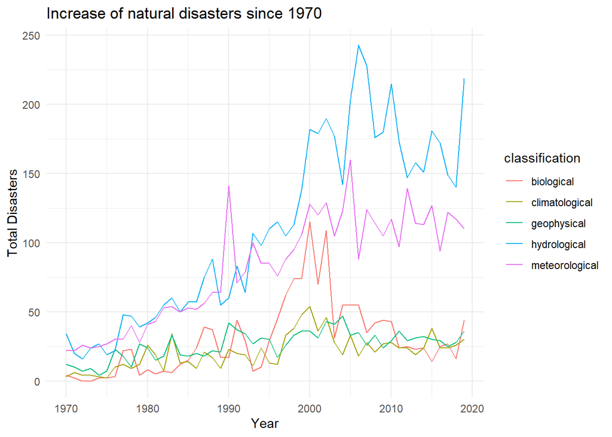

International news headlines share tragic stories of natural disasters causing immense human suffering throughout the developing world. In 1970, one of the strongest tropical storms ever recorded struck Bangladesh and killed at least an estimated 300,000 people. The 2004 Indian Ocean earthquake, the third largest in the 21st century, created the worst tsunami in history, taking the lives of nearly a quarter million people in the countries surrounding the Indian Ocean. More recently, the 2010 Haiti earthquake moved the international community and developed countries to donate nearly 13 billion USD to one of the world’s most fragile countries. Such visible headlines of tragedy in the developing world resonate in the mind of millions.

### Question

This begs a question

- Is it true that less economically developed countries are disproportionately affected by natural disasters?

### Variables

**Independent Variable**

GDP per capita (US$): GDP per capita is gross domestic product divided by midyear population. GDP is the sum of gross value added by all resident producers in the economy plus any product taxes and minus any subsidies not included in the value of the products. It is calculated without making deductions for depreciation of fabricated assets or for depletion and degradation of natural resources.

[*as defined by the World Bank Development Indicators*](https://data.worldbank.org/indicator/NY.GDP.PCAP.CD)

**Dependent variable**

- Total affected: Sum of the injured, affected and left homeless after a disaster
- Affected: People requiring immediate assistance during a period of emergency, i.e. requiring basic survival needs such as food, water, shelter, sanitation and immediate medical assistance

[*as defined by the glossary of the Emergency Events Database(EM-DAT)*](https://www.emdat.be/explanatory-notes)

### Regression analysis

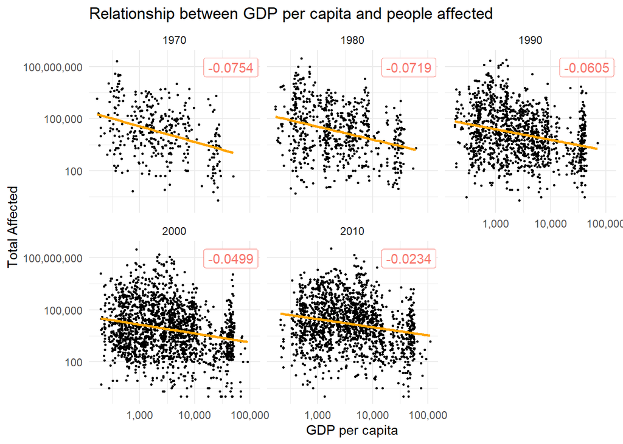

Grouping disasters by decade and testing the relationship between the countries’ GDPs per capita where they occur and Total Affected reveals that this relationship was not very significant to begin with. In fact, it is getting less significant over time as both GDP per capita and disasters increase due to climate change.

GDP per capita alone as a metric for nature disaster preparedness is not sufficient: there is a need to look into other variables that are more significant. Current events such as Australia’s raging bush fires and record-breaking high temperature, or the 2021 Texas power crisis remind us that natural disasters are everyone’s problem.

### Limitations

This study suffers from some potential limitations. First, due to the difficulties of compiling disaster data (especially in the past), the number of observations available is fewer than that of recent years. Second, the observations are based on each countries’ measurements. They are therefore subject to capacity constraints and biases.

### Data Sources

Center for Research on the Epidemiology of Disasters (CRED), The International Disaster Database. (2021). Retrieved at:https://wesr.unep.org/downloader# https://www.emdat.be/

EPA (United States Environmental Protection Agency). *Global Average Absolute Sea Level Change, 1880-2014 from the US Environmental Protection Agency using data from CSIRO, 2015; NOAA, 2015.* Retrieved at: https://datahub.io/core/sea-level-rise

NASA Goddard Institute for Space Studies (GISS). *Surface Temperature Analysis, Global Land-Ocean Temperature Index.* Retrieved at: https://datahub.io/core/global-temp#data

World Bank, World Development Indicators. (2021). *GDP per capita (current USD$)* https://data.worldbank.org/indicator/NY.GDP.PCAP.CD

### Further Reading

Field, C. B., Barros, V., Stocker, T. F., & Dahe, Q. (Eds.). (2012). *Managing the risks of extreme events and disasters to advance climate change adaptation: special report of the intergovernmental panel on climate change.* Cambridge University Press. [Available online at: https://www.ipcc.ch/report/managing-the-risks-of-extreme-events-and-disasters-to-advance-climate-change-adaptation/]

Sendai framework for disaster risk reduction 2015–2030. In: UN world conference on disaster risk reduction, 2015 March 14–18, Sendai, Japan. Geneva: United Nations Office for Disaster Risk Reduction; 2015. Available from: http://www.wcdrr.org/uploads/Sendai_Framework_for_Disaster_Risk_Reduction_2015-2030.pdf